# ggformula/lattice Comparison

Nicholas Horton (nhorton@amherst.edu)

2020-03-05

## Introduction

This document is intended to help users of the `mosaic` package migrate their `lattice` package graphics to `ggformula`. The mosaic package provides a simplified and systematic introduction to the core functionality related to descriptive statistics, visualization, modeling, and simulation-based inference required in first and second courses in statistics.

Originally, the `mosaic` package used `lattice` graphics but now support is also available for the improved `ggformula` system. Going forward, `ggformula` will be the preferred graphics package for Project MOSAIC.

## Histograms

### Histograms (ggformula)

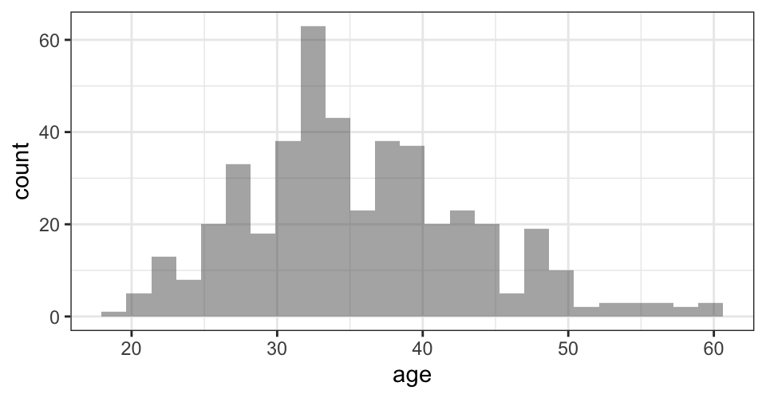

```r
library(mosaic)   # also loads ggformula
gf_histogram(~ age, data = HELPrct)
```

### Histogram options (ggformula)

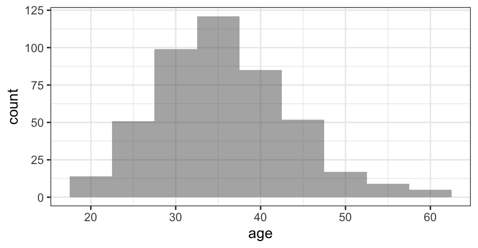

```r
gf_histogram(~ age, data = HELPrct,
             binwidth = 5)
```

### Histograms (lattice)

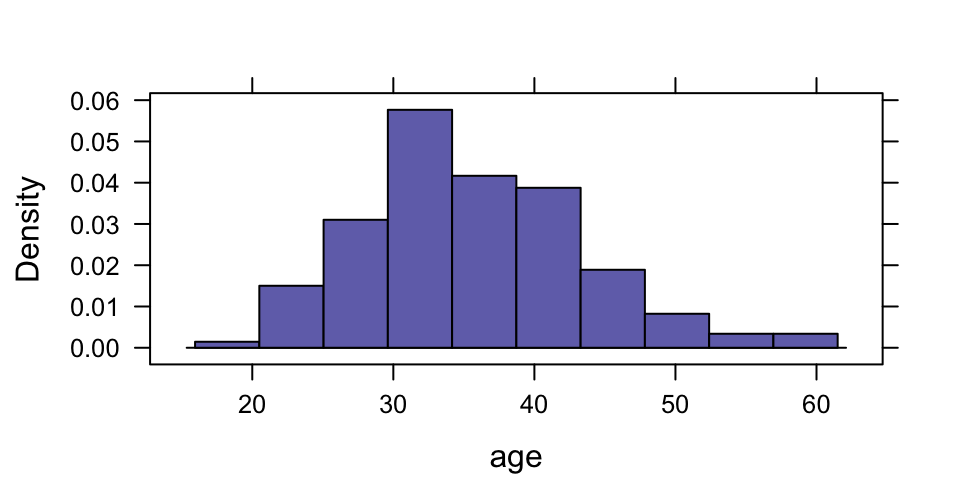

```r
library(mosaic)     # also loads lattice
histogram(~ age, data = HELPrct)
```

### Histogram options (lattice)

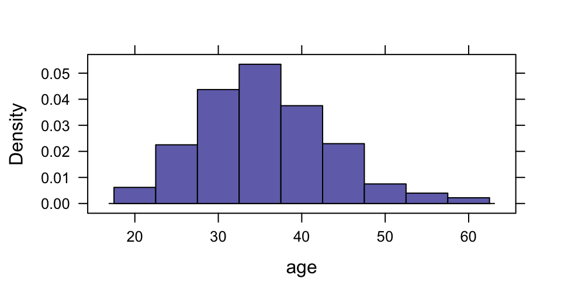

```r
histogram(~ age, width = 5, data = HELPrct)
```

## Density Plots

### Density plots (ggformula)

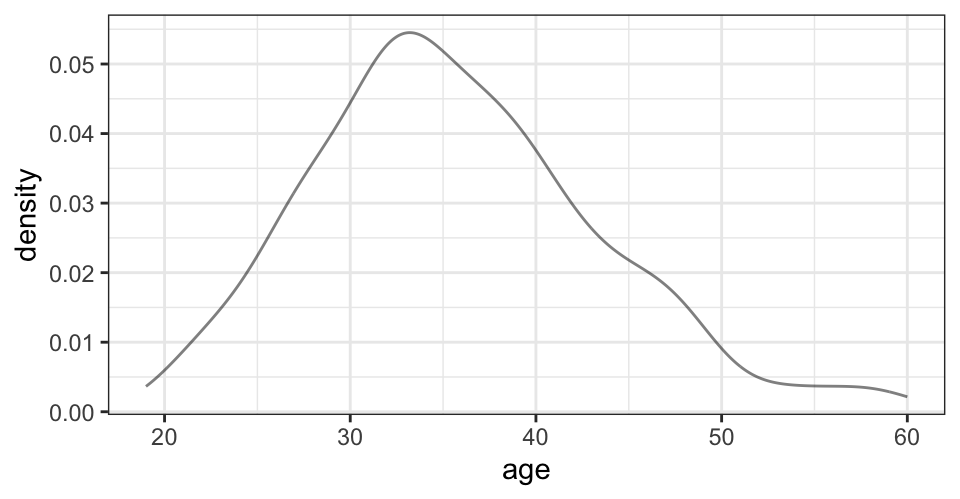

```r
gf_dens(~ age, data = HELPrct)
```

### Overlaid density plots (ggformula)

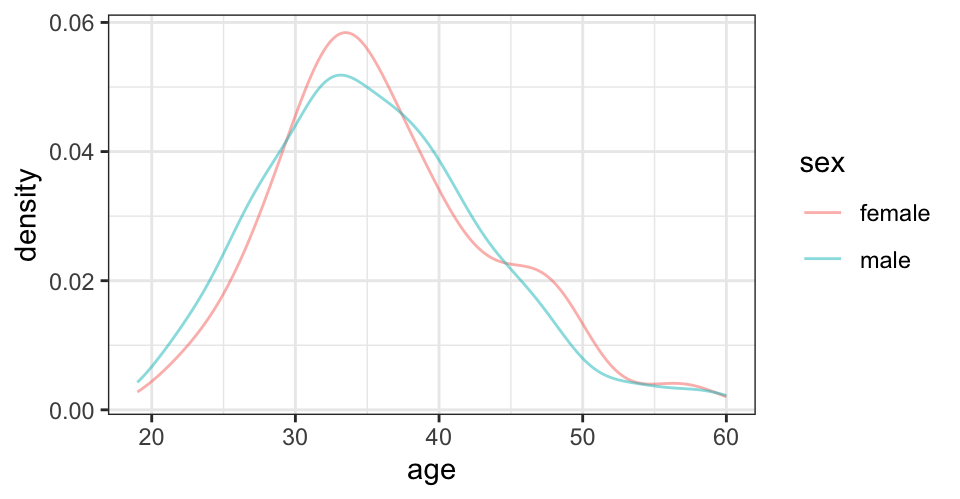

```r
gf_dens(~ age, data = HELPrct,
        color = ~ sex)
```

### Density over histograms (ggformula)

We can use stacked layers to add a density curve based on a maximum likelihood fit or a kernel density estimate (see also `gf_dist()`)

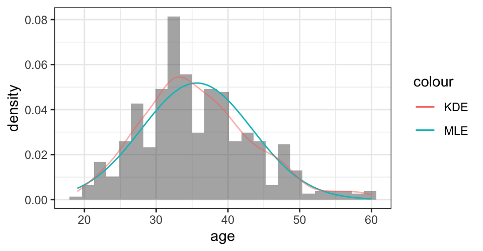

```r
gf_dhistogram( ~ age, data = HELPrct,
               alpha = 0.5) %>%
  gf_fitdistr(color = ~"MLE", dist = "dnorm") %>%
  gf_dens(color = ~"KDE")
```

### Density plots (lattice)

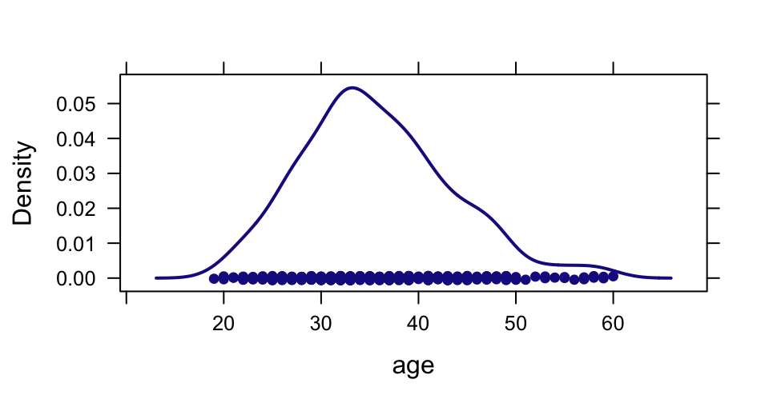

```r
densityplot(~ age, data = HELPrct)
```

### Overlaid density plots (lattice)

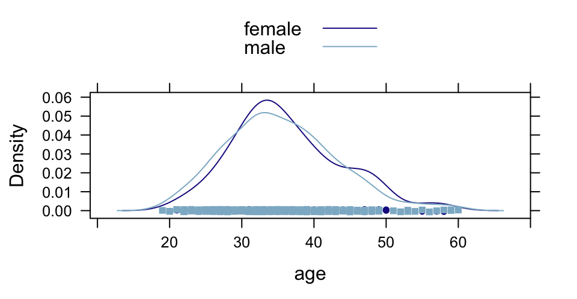

```r
densityplot(~ age, data = HELPrct,
            groups = sex,  auto.key = TRUE)
```

### Density over histograms (lattice)

`mosaic` makes it easy to add a fitted distribution to a histogram.

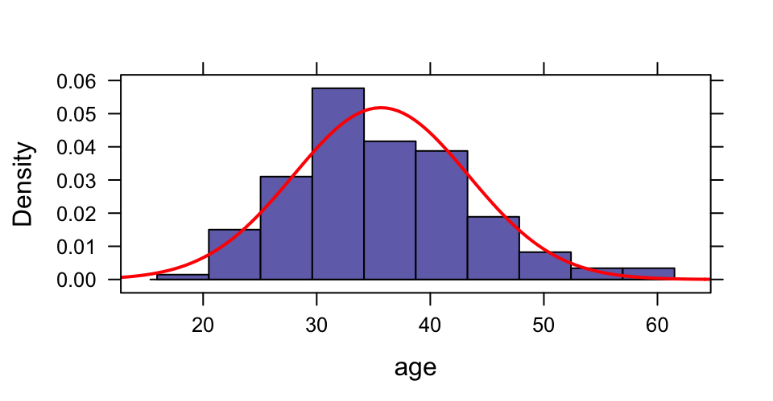

```r
histogram(~ age, data = HELPrct,
          fit = "normal", dcol = "red")
```

## Side by side boxplots

### Side by side boxplots (ggformula)

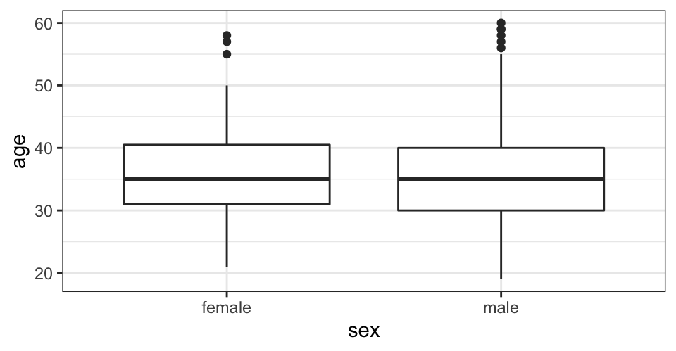

```r
gf_boxplot(age ~ sex, data = HELPrct)
```

### Faceted side by side boxplots (ggformula)

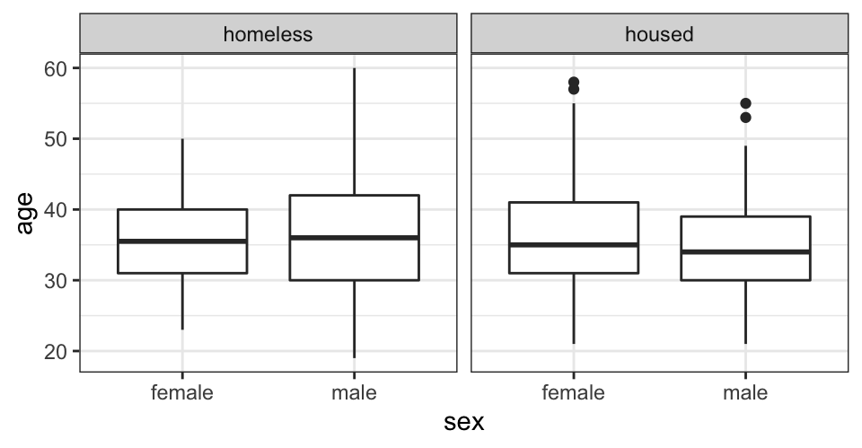

```r
gf_boxplot(age ~ sex | homeless,
  data = HELPrct)
```

### Horizontal boxplots (ggformula)

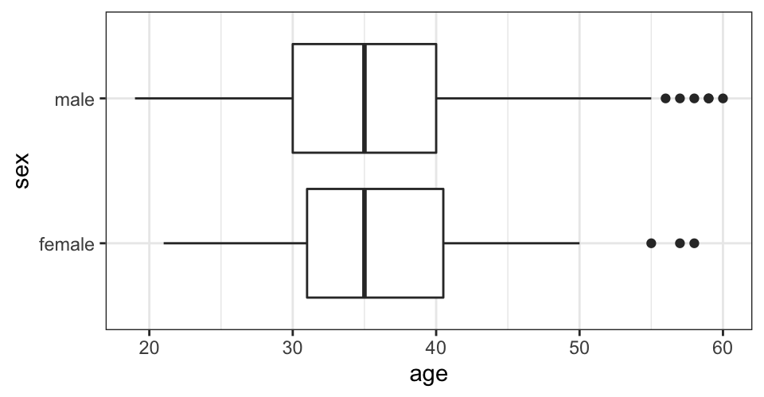

```r
gf_boxploth(sex ~ age, data = HELPrct)
```

### Side by side boxplots (lattice)

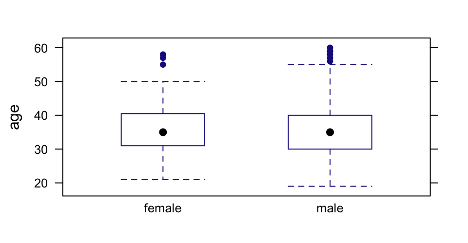

```r
bwplot(age ~ sex, data = HELPrct)
```

### Faceted side by side boxplots (lattice)

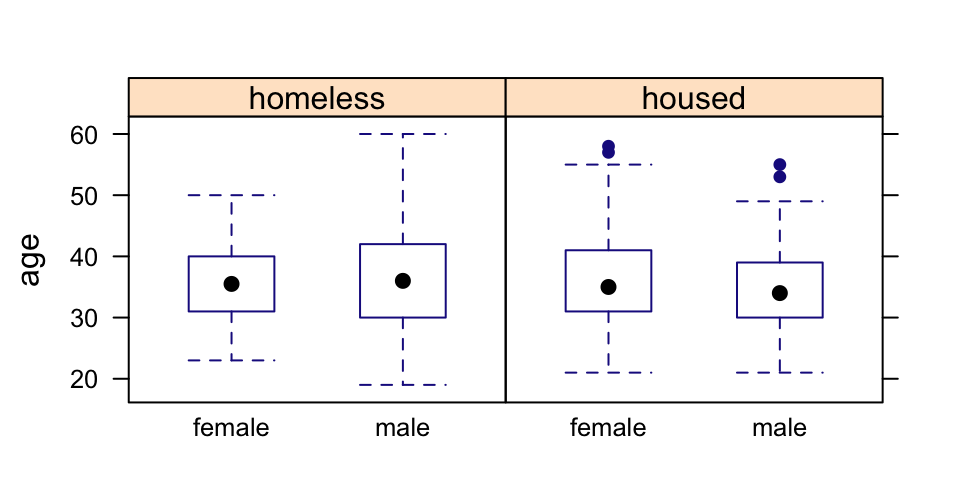

```r
bwplot(age ~ sex | homeless,
       data = HELPrct)
```

### Horizontal boxplots (lattice)

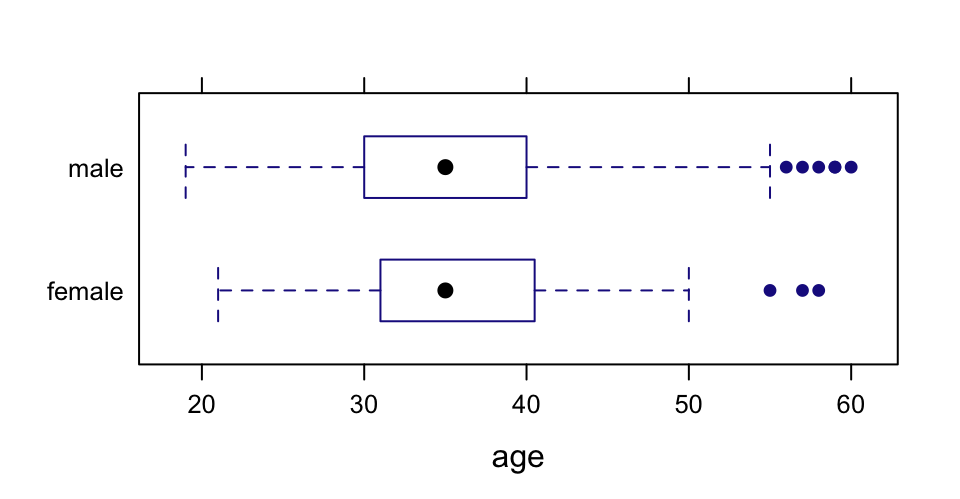

```r
bwplot(sex ~ age, data = HELPrct)
```

## Scatterplots

### Basic scatterplot (ggformula)

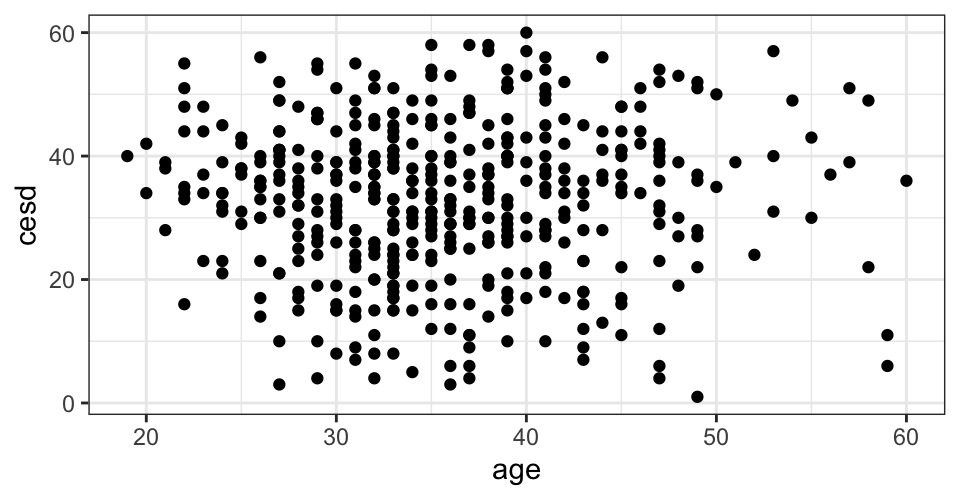

```r
gf_point(cesd ~ age, data = HELPrct)
```

### Overlaid scatterplot with linear fit (ggformula)

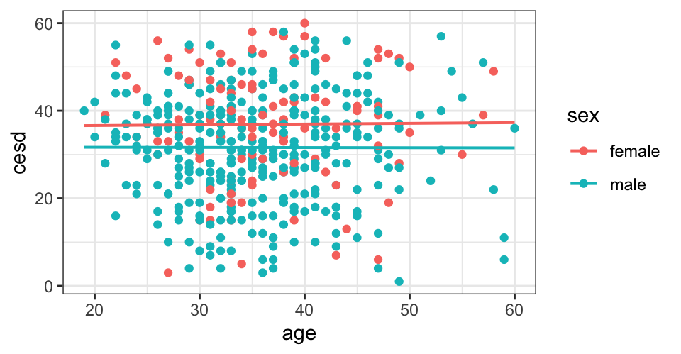

```r
gf_point(cesd ~ age, data = HELPrct,
         color = ~ sex) %>%
  gf_lm()
```

### Basic Scatterplot (lattice)

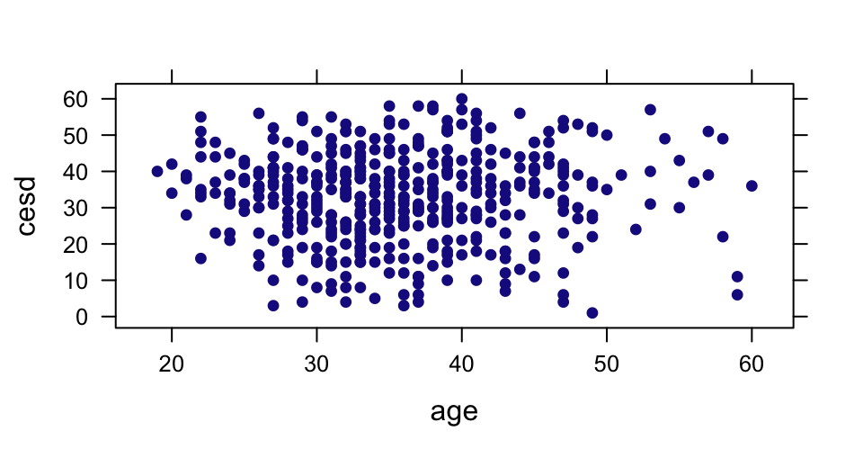

```r
xyplot(cesd ~ age, data = HELPrct)
```

### Overlaid scatterplot with linear fit (lattice)

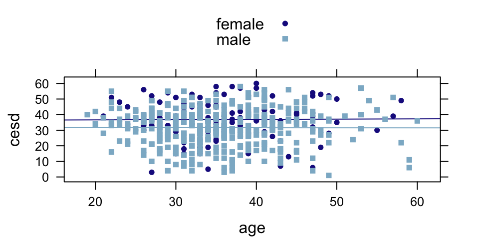

```r
xyplot(cesd ~ age,  data = HELPrct,
       groups = sex,
       type = c("p", "r"),
       auto.key = TRUE)
```

### Faceted scatterplot with smooth fit (ggformula)

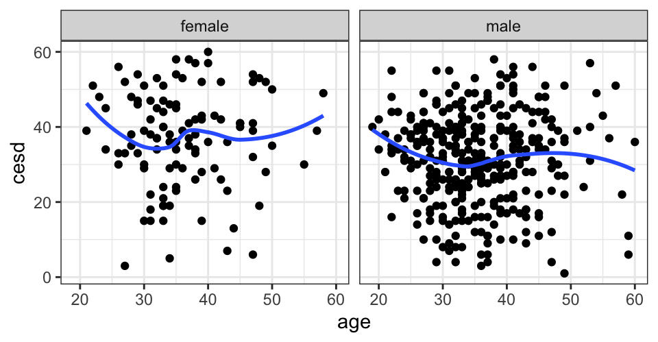

```r
gf_point(cesd ~ age | sex,
         data = HELPrct) %>%
  gf_smooth(se = FALSE)
```

## More options for scatterplot with linear fit (ggformula)

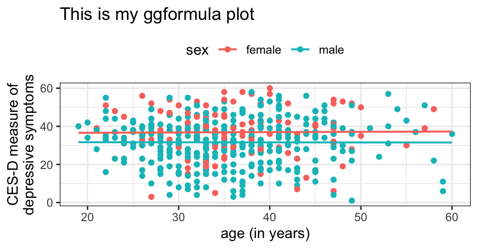

```r
gf_point(cesd ~ age, data = HELPrct,
         color = ~ sex) %>%
  gf_lm() %>%
  gf_theme(legend.position = "top") %>%
  gf_labs(
    title = "This is my ggformula plot",
    x     = "age (in years)",
    y     = "CES-D measure of
depressive symptoms")
```

## Faceted scatterplot with smooth fit (lattice)

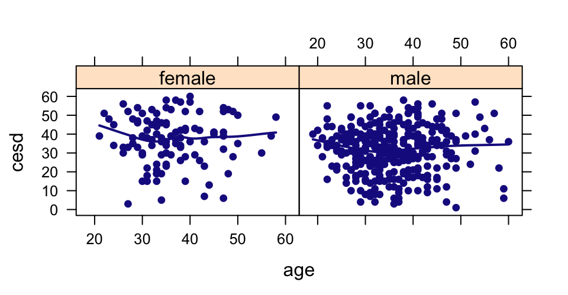

```r
xyplot(cesd ~ age | sex,  data = HELPrct,
       type = c("p", "smooth"),
       auto.key = TRUE)
```

## More options for scatterplot with linear fit (lattice)

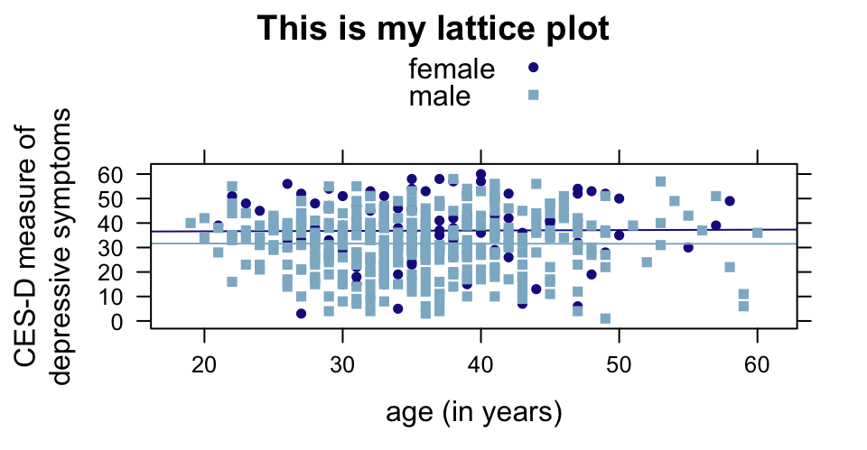

```r
xyplot(cesd ~ age, groups = sex,
       type = c("p", "r"),
       auto.key = TRUE,
       main = "This is my lattice plot",
       xlab = "age (in years)",
       ylab = "CES-D measure of
depressive symptoms",
       data = HELPrct)
```

## Refining graphs

### Log scales (ggformula)

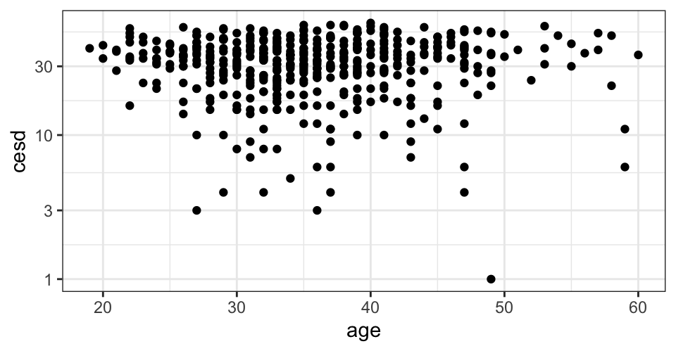

```r
gf_point(cesd ~ age, data = HELPrct) %>%
  gf_refine(scale_y_log10())
```

### Custom Colors (ggformula)

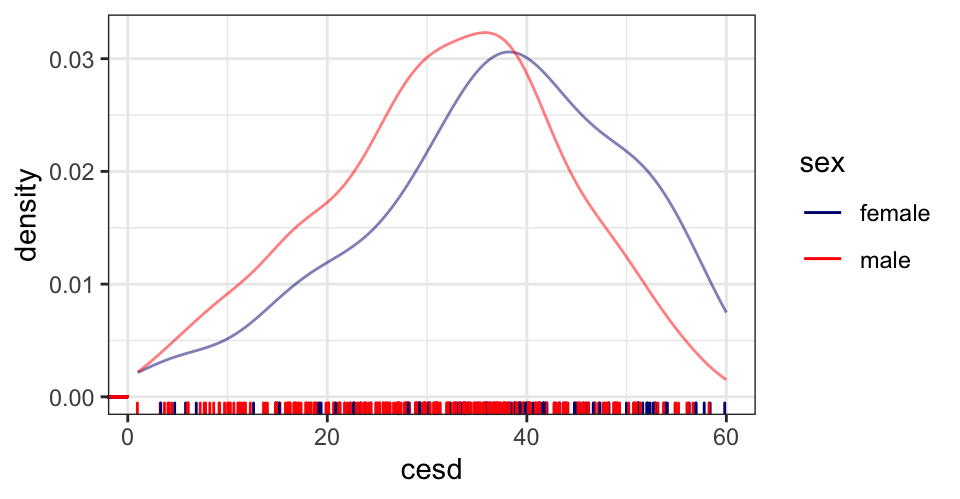

```r
gf_dens(
  ~ cesd, data = HELPrct,
  color = ~ sex) %>%
  gf_rug(
    0 ~ cesd,
    position = position_jitter(height = 0)
  ) %>%
  gf_refine(
    scale_color_manual(
      values = c("navy", "red")))
```

### Log scales (lattice)

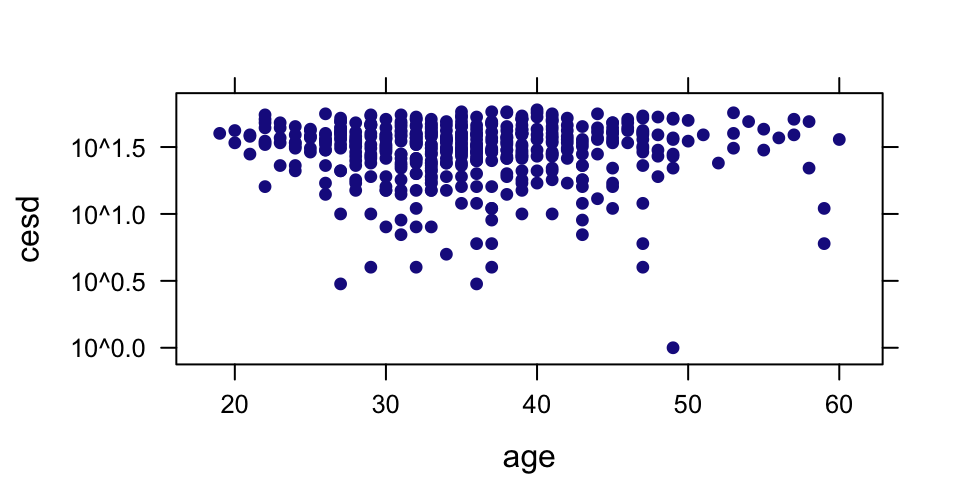

```r
xyplot(
  cesd ~ age, data = HELPrct,
  scales = list(y = list(log = TRUE)))
```

### Custom Colors (lattice)

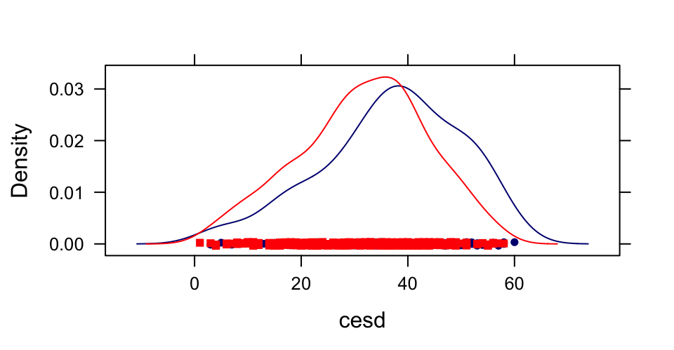

```r
densityplot(
  ~ cesd, data = HELPrct, groups = sex,
  rug = FALSE,
  par.settings =
    list(
      superpose.line =
        list(col = c("navy", "red")),
      superpose.symbol =
        list(col = c("navy", "red"))
    ))
```

## Want to explore more?

Within RStudio, after loading the `mosaic` package, try running the command `mplot(ds)` where `ds` is a dataframe. This will open up an interactive visualizer that will output the code to generate the figure (using `lattice`, `ggplot2`, or `ggformula`) when you click on `Show Expression`.

## References

More information about `ggformula` can be found at https://projectmosaic.github.io/ggformula.

More information regarding Project MOSAIC (Kaplan, Pruim, and Horton) can be found at http://www.mosaic-web.org. Further information regarding the `mosaic` package can be found at https://projectmosaic.github.io/mosaic and https://journal.r-project.org/archive/2017/RJ-2017-024.

Examples of how to bring multidimensional graphics into day one of an introductory statistics course can be found at http://escholarship.org/uc/item/84v3774z.